# Linear models 2

## Learning outcomes

- Assumptions.
- Adding more covariates.
- The \(F\)-test.
- Models with factor variables.

## Recall: The linear model

- The linear model estimates the mean of the response variable for given values of a covariate \[ \mathsf{mean}(y) = \alpha + \beta x \]
- The model is fit by finding least squares estimates for \(\alpha\) and \(\beta\).
- The model assumptions are defined in terms of the residuals.
- When the assumptions hold we can take our model from the sample and generalise to the population.

## Assumptions

## Assumptions of linear models

**L**inearity

- Residuals don’t depend on \(x\).

**I**ndependence

- Residuals don’t depend on each other.

**N**ormality

- Residuals are distributed normally.

**E**qual variance

- Residuals have constant variance.

## Checking the assumptions

- We can check the linear model assumptions by producing **diagnostic plots** of the model.
- Using these, we can assess linearity, normality, and equal variance, but we usually can’t assess independence without using other information from the data (such as how it was collected).
- In addition, we can also see whether there are outliers in the data that have undue **influence** on our model fit.
- In RStudio, we can use `plot(model)` to get diagnostic plots.

## Example: Donkeys

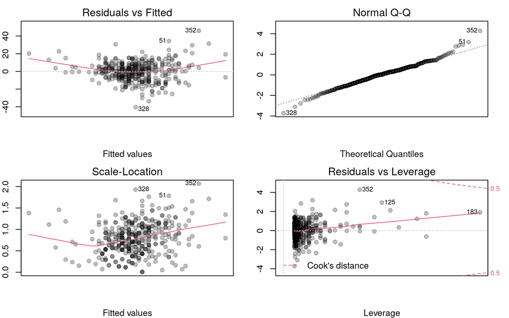

## Donkeys: Residuals vs Fitted values

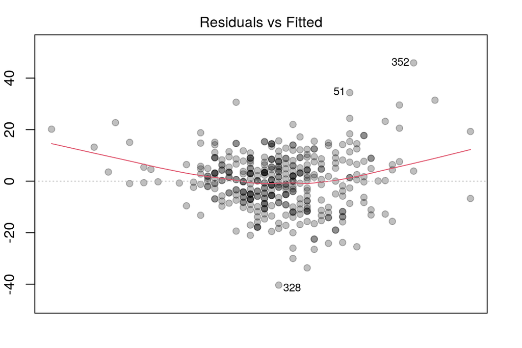

Linearity doesn’t hold. There is a curve.

Equal variance doesn’t hold. There is fanning in the residuals.

## Donkeys: Original scale

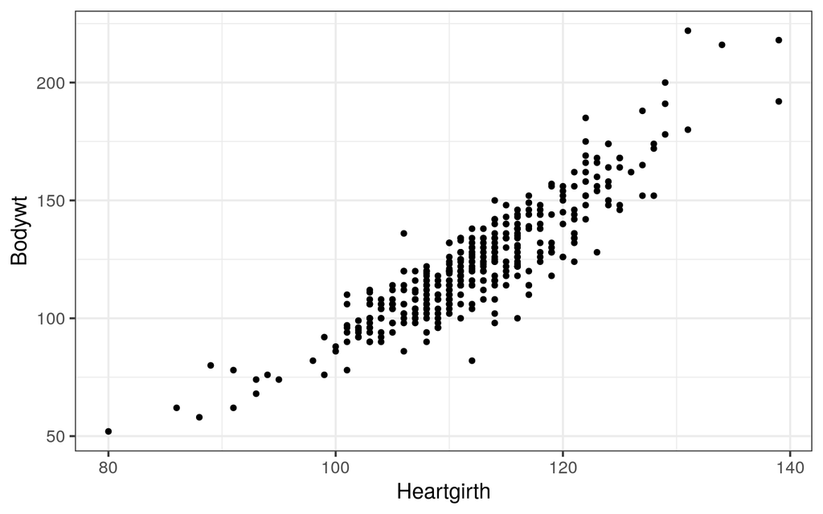

## Donkeys: Log scale

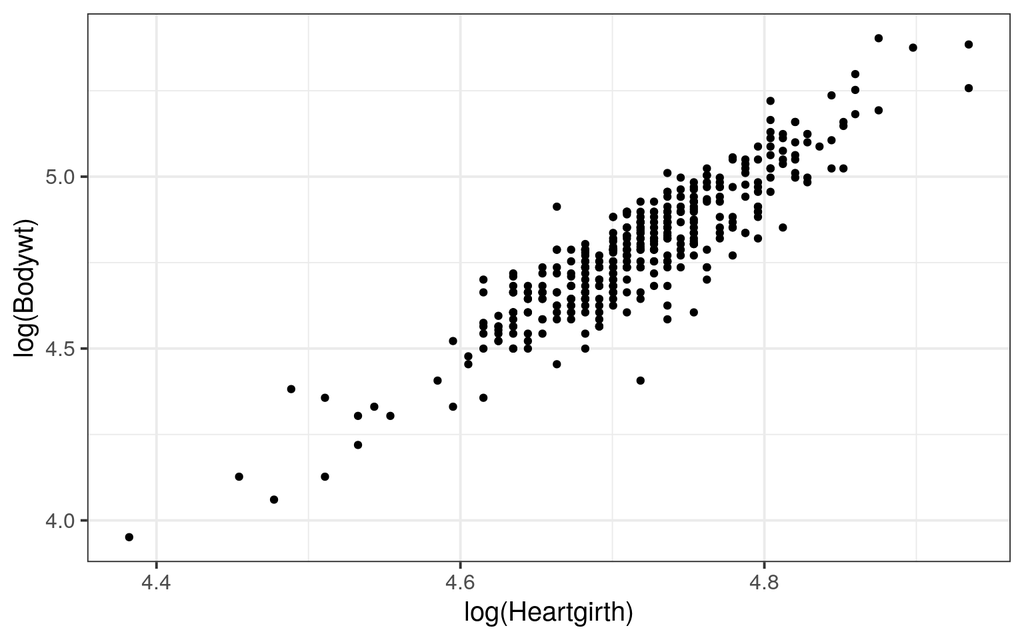

## Fit log scale model and plot

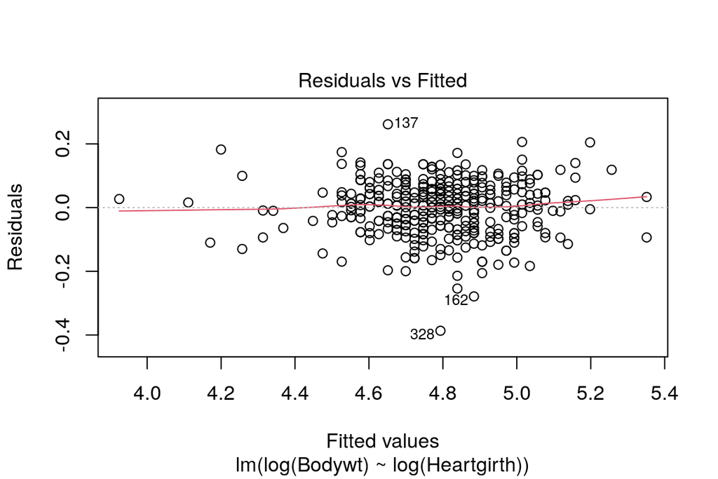

Linearity and equal variance now hold.

## What have we done?

- We transformed the data and then fit a straight line.
- This is the same as fitting a curve to the original data (a power curve).
- We can visualise that using `visreg`. We’ll learn this in lab 2.

```r
library(visreg)
visreg(mod2)
```

## Visualising the model

[figure not shown]

## Visualising the model

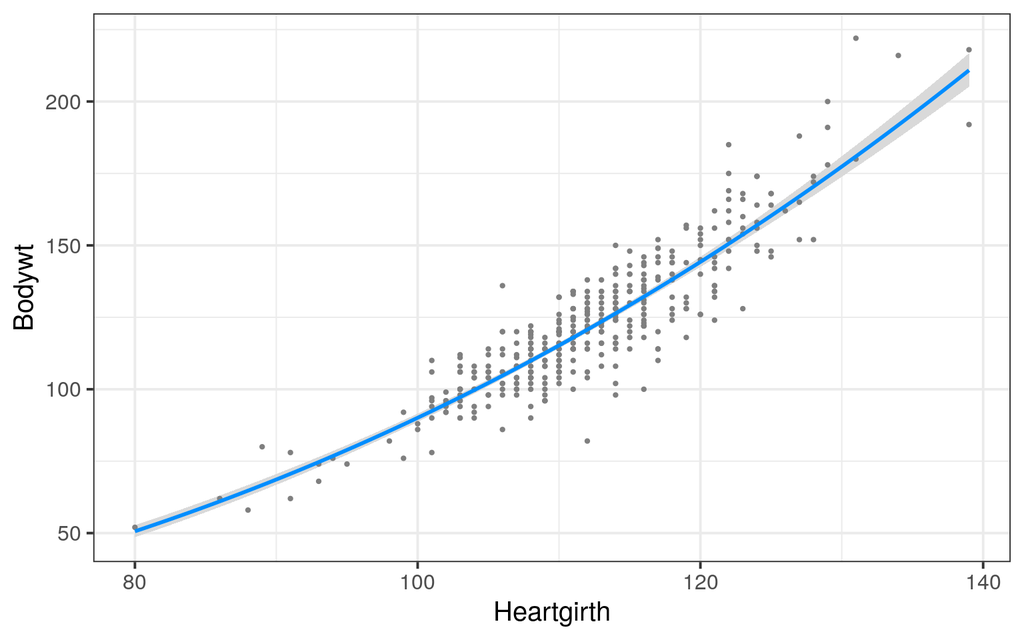

## Summary

- The residuals vs fitted plot should be looked at first. If you see curvature or increasing scatter from left to right, try a log transform and re-fit the model.
- Next look at residuals vs leverage. If you have influential outliers then look at the effect of removing those observations.

## The Linear model

### Multiple covariates

## Relationships: Donkeys

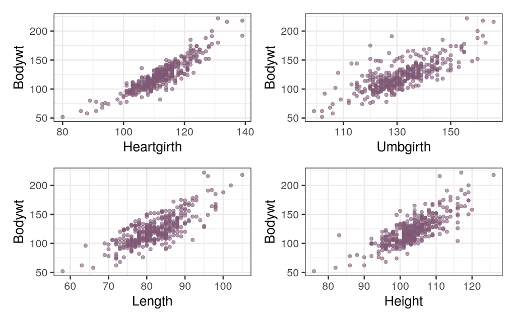

## Relationships: Donkeys

- There are reasonably strong increasing relationships between body weight and hearth girth, umbilical girth, length and height.
- It makes sense to use all of these variables to predict the body weight.
- That way we’re likely to explain more of the variation in body weight.
- Predictions will be more precise (smaller confidence and prediction intervals).

## Multiple covariates

- Adding extra covariates is as simple as adding another term to the linear model equation. \[ \mathsf{mean}(y) = \alpha + \beta_1 x_1 + \beta_2 x_2 + \cdots \]
- We find least squares estimates for \(\alpha\), \(\beta_1, \beta_2, \ldots\) in the same way, by minimising the residual sum of squares.
- As the model assumptions are defined in terms of the residuals, the complexity of the model equation doesn’t change things much.
- We get additional lines in our output for each covariate we add to the model.

## Sidenote: Matrix version of the linear model

We can formulate the linear model in terms of a **matrix equation** \[ Y = X \beta + \epsilon \] where \(Y\) is a vector of the dependent variable measurements, \(X\) is the **design matrix** of covariate values, \(\beta\) is a vector of coefficients (to be estimated) and \(\epsilon\) is a vector of residuals. The form \(X\) takes is \[ X = \left[\begin{array}{c c c c} 1 & x_{11} & \cdots & x_{p1}\\ 1 & x_{12} & \cdots & x_{p2}\\ \vdots & \vdots & \ddots & \vdots\\ 1 & x_{1n} & \cdots & x_{pn} \end{array}\right] \] where \(p\) is the number of covariates, and \(n\) is the number of observations.

## Example: Donkeys

```
Call:
lm(formula = Bodywt ~ Heartgirth, data = donkey)

Residuals:
    Min      1Q  Median      3Q     Max
-40.343  -6.829   0.486   6.432  45.909

Coefficients:
              Estimate Std. Error t value Pr(>|t|)
(Intercept) -194.48580    7.99203  -24.34   <2e-16 ***
Heartgirth     2.82883    0.07118   39.74   <2e-16 ***
---
Signif. codes:  0 '***' 0.001 '**' 0.01 '*' 0.05 '.' 0.1 ' ' 1

Residual standard error: 10.83 on 383 degrees of freedom
Multiple R-squared:  0.8048,    Adjusted R-squared:  0.8043
F-statistic:  1580 on 1 and 383 DF,  p-value: < 2.2e-16
```

## Example: Donkeys

```
Call:
lm(formula = Bodywt ~ Heartgirth + Umbgirth, data = donkey)

Residuals:
    Min      1Q  Median      3Q     Max
-34.651  -6.349   0.749   5.902  43.932

Coefficients:
              Estimate Std. Error t value Pr(>|t|)
(Intercept) -200.64500    7.75418  -25.88  < 2e-16 ***
Heartgirth     2.38832    0.10290   23.21  < 2e-16 ***
Umbgirth       0.42207    0.07366    5.73 2.04e-08 ***
---
Signif. codes:  0 '***' 0.001 '**' 0.01 '*' 0.05 '.' 0.1 ' ' 1

Residual standard error: 10.41 on 382 degrees of freedom
Multiple R-squared:  0.8203,    Adjusted R-squared:  0.8193
F-statistic: 871.8 on 2 and 382 DF,  p-value: < 2.2e-16
```

## Testing multiple covariates

- We don’t want to just answer the question **“Which of the variables are important?”**
- Rather, we want to answer **“Which of the variables are important *after accounting for the other variables*?”**
- This is equivalent to: **“Which of the \(\beta\)’s are non-zero?”**

## Summary output for multiple covariates

```
Call:
lm(formula = Bodywt ~ Heartgirth + Umbgirth + Length + Height,
    data = donkey)

Residuals:
    Min      1Q  Median      3Q     Max
-26.156  -5.960   0.025   5.376  42.189

Coefficients:
              Estimate Std. Error t value Pr(>|t|)
(Intercept) -222.33956    8.01411 -27.744  < 2e-16 ***
Heartgirth     1.76223    0.12784  13.784  < 2e-16 ***
Umbgirth       0.37418    0.06726   5.563 5.01e-08 ***
Length         0.87580    0.11531   7.595 2.41e-13 ***
Height         0.25407    0.13749   1.848   0.0654 .
---
Signif. codes:  0 '***' 0.001 '**' 0.01 '*' 0.05 '.' 0.1 ' ' 1

Residual standard error: 9.476 on 380 degrees of freedom
Multiple R-squared:  0.8519,    Adjusted R-squared:  0.8503
F-statistic: 546.4 on 4 and 380 DF,  p-value: < 2.2e-16
```

## Summary output for multiple covariates

- Heart girth, umbilical girth and length are all important after accounting for other covariates.
- Height is not important after accounting for the other covariates.
- **This doesn’t mean that height isn’t important for body weight!**

## But wait!

```
Call:
lm(formula = Bodywt ~ Height, data = donkey)

Residuals:
    Min      1Q  Median      3Q     Max
-56.065  -9.782  -0.835  10.041  71.024

Coefficients:
             Estimate Std. Error t value Pr(>|t|)
(Intercept) -189.9836    12.7034  -14.96   <2e-16 ***
Height         3.0177     0.1225   24.64   <2e-16 ***
---
Signif. codes:  0 '***' 0.001 '**' 0.01 '*' 0.05 '.' 0.1 ' ' 1

Residual standard error: 15.25 on 383 degrees of freedom
Multiple R-squared:  0.6131,    Adjusted R-squared:  0.6121
F-statistic: 606.9 on 1 and 383 DF,  p-value: < 2.2e-16
```

## Summary output for multiple covariates

- Heart girth, umbilical girth and length are all important after accounting for other covariates.
- Height is not important after accounting for the other covariates.
- The \(R^2\) for the model is 0.852, so the model is explaining 85.2% of the variation in body weight.
- What is the overall P-value telling us?

## The F-test

## The F-test

- One of the first things we want to know is whether anything at all in our model is useful.
- The hypothesis to test is **“Are any of the \(\beta\)’s non-zero?”**
- We can do this by comparing the variation in the residuals to the total variation in \(y\).
- We use the **F-statistic** for this. It’s similar to \(R^2\), but results in nicer maths. \[ F = \frac{\mathsf{Variation\ explained}}{\mathsf{Variation\ unexplained}} = \frac{(\sigma^2_\mathsf{total} - \sigma^2_\mathsf{res})/p}{\sigma^2_\mathsf{res}/(n-p-1)} \] where \(p\) is the number of covariates, and \(n\) the number of observations.
- This process is also known as **ANalysis Of VAriance** or **ANOVA**.

## The F-test

\[ F = \frac{\mathsf{Variation\ explained}}{\mathsf{Variation\ unexplained}} = \frac{(\sigma^2_\mathsf{total} - \sigma^2_\mathsf{res})/p}{\sigma^2_\mathsf{res}/(n-p-1)} \]

## The F-statistic in summary output

```
Coefficients:
              Estimate Std. Error t value Pr(>|t|)
(Intercept) -222.33956    8.01411 -27.744  < 2e-16 ***
Heartgirth     1.76223    0.12784  13.784  < 2e-16 ***
Umbgirth       0.37418    0.06726   5.563 5.01e-08 ***
Length         0.87580    0.11531   7.595 2.41e-13 ***
Height         0.25407    0.13749   1.848   0.0654 .
---
Signif. codes:  0 ‘***’ 0.001 ‘**’ 0.01 ‘*’ 0.05 ‘.’ 0.1 ‘ ’ 1

Residual standard error: 9.476 on 380 degrees of freedom
Multiple R-squared:  0.8519,    Adjusted R-squared:  0.8503
F-statistic: 546.4 on 4 and 380 DF,  p-value: < 2.2e-16
```

An F value of 546.4 is really unlikely to arise by chance, so our model is telling us something about body weight.

## Linear models with factors

## Linear models with factors

- The linear model equation is describing the **mean** of the outcome variable given the value of the covariates.
- When we have a factor, or categorical covariate, the linear model will estimate the mean within each group.
- To do this, we’ll need to convert the categorical variable to a numeric variable in some way.

## Factors with two levels

- For a factor with two levels, we can do this by introducing an **indicator variable** \(z\) as a covariate, where \[ z = \left\{ \begin{array}{ll} 0 & \textrm{for observations in level 1}\\ 1 & \textrm{for observations in level 2} \end{array}\right. \]
- The equation is then \[ \mathsf{mean}(y) = \alpha + \beta z \]

## Factors with two levels

- The equation is then \[ \mathsf{mean}(y) = \alpha + \beta z \]
- For observations in level 1 we know \(z=0\), so the equation gives \[ \mathsf{mean}(y) = \alpha \]
- For observations in level 2 we know \(z=1\), so the equation gives \[ \mathsf{mean}(y) = \alpha + \beta \]
- Thus, \(\beta\) represents the **difference** between level 1 and 2.
- Testing for a difference between groups is then just testing whether \(\beta = 0\).

## Example: Donkeys

```r
mod <- lm(Bodywt ~ Sex, data=donkey)
summary(mod)
```

```
Call:
lm(formula = Bodywt ~ Sex, data = donkey)

Residuals:
    Min      1Q  Median      3Q     Max
-71.161 -15.387  -3.161  10.839  98.839

Coefficients:
            Estimate Std. Error t value Pr(>|t|)
(Intercept)  121.387      1.891  64.194   <2e-16 ***
SexMale        1.774      2.519   0.704    0.482
---
Signif. codes:  0 '***' 0.001 '**' 0.01 '*' 0.05 '.' 0.1 ' ' 1

Residual standard error: 24.51 on 383 degrees of freedom
Multiple R-squared:  0.001294,  Adjusted R-squared:  -0.001313
F-statistic: 0.4963 on 1 and 383 DF,  p-value: 0.4816
```

## Example: Donkeys

- The intercept is the mean body weight of female donkeys (121.4 kg).
- The coefficient labelled `SexMale` is the difference between females and males (males 1.77 kg heavier).
- This difference isn’t significant (P=0.482).
- This is **exactly the same** as a two sample t-test where we assume the variance in each group is the same.

## Example: Donkeys

```r
t.test(Bodywt ~ Sex, data=donkey, var.equal=TRUE)
```

```
    Two Sample t-test

data:  Bodywt by Sex
t = -0.70448, df = 383, p-value = 0.4816
alternative hypothesis: true difference in means is not equal to 0
95 percent confidence interval:
 -6.726609  3.177838
sample estimates:
mean in group Female   mean in group Male
            121.3869             123.1613
```

**Linear model gives same results!**

## What about three levels?

- For two levels we introduced an indicator variable that was 1 when we were in level 2 and 0 otherwise.
- For three levels we introduce two indicator variables:
  - \(z_2 = 1\) if the observation is in level 2, \(z_2 = 0\) otherwise.
  - \(z_3 = 1\) if the observation is in level 3, \(z_3 = 0\) otherwise.
- The linear model is then \[ \mathsf{mean}(y) = \alpha + \beta_2 z_{2} + \beta_3 z_{3} \] where \(\beta_2\) is the difference between level 1 and level 2, and \(\beta_3\) is the difference between level 1 and level 3.

## What about three levels?

- The linear model is then \[ \mathsf{mean}(y) = \alpha + \beta_2 z_{2} + \beta_3 z_{3} \]
- The primary hypothesis to test is “Is there any difference between the three levels?”.
- This is the same as “Are any of the \(\beta\)’s non-zero?”
- The F-test, or Analysis of Variance!

## Example: Petrels

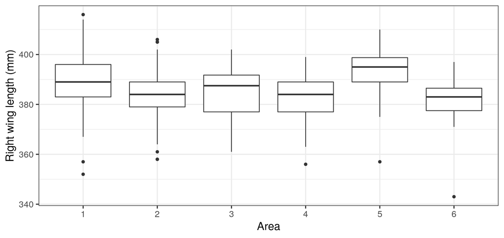

## Example: Petrels

```
Call:
lm(formula = R.Wing.Lth ~ Area, data = petrels)

Residuals:
    Min      1Q  Median      3Q     Max
-37.600  -5.486   0.400   5.404  26.400

Coefficients:
            Estimate Std. Error t value Pr(>|t|)
(Intercept) 389.6000     0.5432 717.238  < 2e-16 ***
Area2        -6.0036     0.8077  -7.433 3.09e-13 ***
Area3        -5.2250     2.2966  -2.275 0.023199 *
Area4        -6.6893     1.3106  -5.104 4.29e-07 ***
Area5         4.1462     0.9528   4.351 1.55e-05 ***
Area6        -9.2667     2.6332  -3.519 0.000461 ***
---
Signif. codes:  0 '***' 0.001 '**' 0.01 '*' 0.05 '.' 0.1 ' ' 1

Residual standard error: 8.926 on 701 degrees of freedom
Multiple R-squared:  0.1719,    Adjusted R-squared:  0.166
F-statistic: 29.11 on 5 and 701 DF,  p-value: < 2.2e-16
```

## Example: Petrels

```r
new_data <- data.frame(Area=factor(1:6))
predict(mod, new_data, interval="confidence")
```

```
       fit      lwr      upr
1 389.6000 388.5335 390.6665
2 383.5964 382.4229 384.7699
3 384.3750 379.9940 388.7560
4 382.9107 380.5690 385.2525
5 393.7462 392.2092 395.2831
6 380.3333 375.2746 385.3921
```

## Visualising the differences

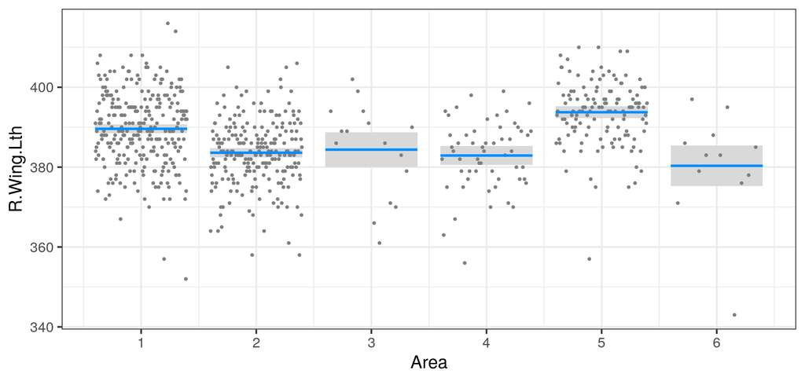

```r
library(visreg)
visreg(mod)
```